# Part I - Prosper Loan Data Dataset Exploration

## Introduction

> This data set contains 113,937 loans with 81 variables on each loan; including loan amount, borrower rate (or interest rate), current loan status, borrower income, employment status, listing category, term, prosper rating and many other variables.

## Preliminary Wrangling

```python
# import all packages and set plots to be embedded inline
import numpy as np
import pandas as pd
import matplotlib.pyplot as plt
import seaborn as sns

%matplotlib inline
```

```python
# load in the dataset into a pandas dataframe
prosper = pd.read_csv('prosperLoanData.csv');
prosper.head(5)
```

|  | ListingKey | ListingNumber | ListingCreationDate | CreditGrade | Term | LoanStatus | ClosedDate | BorrowerAPR | BorrowerRate | LenderYield | ... | LP_ServiceFees | LP_CollectionFees | LP_GrossPrincipalLoss | LP_NetPrincipalLoss | LP_NonPrincipalRecoverypayments | PercentFunded | Recommendations | InvestmentFromFriendsCount | InvestmentFromFriendsAmount | Investors |
| --- | --- | --- | --- | --- | --- | --- | --- | --- | --- | --- | --- | --- | --- | --- | --- | --- | --- | --- | --- | --- | --- |
| 0 | 1021339766868145413AB3B | 193129 | 2007-08-26 19:09:29.263000000 | C | 36 | Completed | 2009-08-14 00:00:00 | 0.16516 | 0.1580 | 0.1380 | ... | -133.18 | 0.0 | 0.0 | 0.0 | 0.0 | 1.0 | 0 | 0 | 0.0 | 258 |
| 1 | 10273602499503308B223C1 | 1209647 | 2014-02-27 08:28:07.900000000 | NaN | 36 | Current | NaN | 0.12016 | 0.0920 | 0.0820 | ... | 0.00 | 0.0 | 0.0 | 0.0 | 0.0 | 1.0 | 0 | 0 | 0.0 | 1 |
| 2 | 0EE9337825851032864889A | 81716 | 2007-01-05 15:00:47.090000000 | HR | 36 | Completed | 2009-12-17 00:00:00 | 0.28269 | 0.2750 | 0.2400 | ... | -24.20 | 0.0 | 0.0 | 0.0 | 0.0 | 1.0 | 0 | 0 | 0.0 | 41 |
| 3 | 0EF5356002482715299901A | 658116 | 2012-10-22 11:02:35.010000000 | NaN | 36 | Current | NaN | 0.12528 | 0.0974 | 0.0874 | ... | -108.01 | 0.0 | 0.0 | 0.0 | 0.0 | 1.0 | 0 | 0 | 0.0 | 158 |
| 4 | 0F023589499656230C5E3E2 | 909464 | 2013-09-14 18:38:39.097000000 | NaN | 36 | Current | NaN | 0.24614 | 0.2085 | 0.1985 | ... | -60.27 | 0.0 | 0.0 | 0.0 | 0.0 | 1.0 | 0 | 0 | 0.0 | 20 |

5 rows × 81 columns

```python
prosper.shape
```

```
(113937, 81)
```

```python
prosper.info()
```

```
<class 'pandas.core.frame.DataFrame'>
RangeIndex: 113937 entries, 0 to 113936
Data columns (total 81 columns):
 #   Column                               Non-Null Count   Dtype
---  ------                               --------------   -----
 0   ListingKey                           113937 non-null  object
 1   ListingNumber                        113937 non-null  int64
 2   ListingCreationDate                  113937 non-null  object
 3   CreditGrade                          28953 non-null   object
 4   Term                                 113937 non-null  int64
 5   LoanStatus                           113937 non-null  object
 6   ClosedDate                           55089 non-null   object
 7   BorrowerAPR                          113912 non-null  float64
 8   BorrowerRate                         113937 non-null  float64
 9   LenderYield                          113937 non-null  float64
```

[output cut: 73 more lines]

```python
# Create a subset of the dataframe with fewer variables for the investigation

prosper_columns = ['Term', 'LoanStatus', 'BorrowerAPR', 'ProsperRating (Alpha)', 'EmploymentStatus', 'StatedMonthlyIncome', 'LoanOriginalAmount']
prosper = prosper[prosper_columns]
```

```python
# Describe the properties of the new dataframe
```

```python
prosper.shape
```

```
(113937, 7)
```

```python
prosper.info()
```

```
<class 'pandas.core.frame.DataFrame'>
RangeIndex: 113937 entries, 0 to 113936
Data columns (total 7 columns):
 #   Column                 Non-Null Count   Dtype
---  ------                 --------------   -----
 0   Term                   113937 non-null  int64
 1   LoanStatus             113937 non-null  object
 2   BorrowerAPR            113912 non-null  float64
 3   ProsperRating (Alpha)  84853 non-null   object
 4   EmploymentStatus       111682 non-null  object
 5   StatedMonthlyIncome    113937 non-null  float64
 6   LoanOriginalAmount     113937 non-null  int64
dtypes: float64(2), int64(2), object(3)
memory usage: 6.1+ MB
```

```python
prosper.head(10)
```

|  | Term | LoanStatus | BorrowerAPR | ProsperRating (Alpha) | EmploymentStatus | StatedMonthlyIncome | LoanOriginalAmount |
| --- | --- | --- | --- | --- | --- | --- | --- |
| 0 | 36 | Completed | 0.16516 | NaN | Self-employed | 3083.333333 | 9425 |
| 1 | 36 | Current | 0.12016 | A | Employed | 6125.000000 | 10000 |
| 2 | 36 | Completed | 0.28269 | NaN | Not available | 2083.333333 | 3001 |
| 3 | 36 | Current | 0.12528 | A | Employed | 2875.000000 | 10000 |
| 4 | 36 | Current | 0.24614 | D | Employed | 9583.333333 | 15000 |
| 5 | 60 | Current | 0.15425 | B | Employed | 8333.333333 | 15000 |
| 6 | 36 | Current | 0.31032 | E | Employed | 2083.333333 | 3000 |
| 7 | 36 | Current | 0.23939 | C | Employed | 3355.750000 | 10000 |
| 8 | 36 | Current | 0.07620 | AA | Employed | 3333.333333 | 10000 |
| 9 | 36 | Current | 0.07620 | AA | Employed | 3333.333333 | 10000 |

```python
prosper.EmploymentStatus.unique()
```

```
array(['Self-employed', 'Employed', 'Not available', 'Full-time', 'Other',
       nan, 'Not employed', 'Part-time', 'Retired'], dtype=object)
```

```python
prosper['ProsperRating (Alpha)'].unique()
```

```
array([nan, 'A', 'D', 'B', 'E', 'C', 'AA', 'HR'], dtype=object)
```

```python
#Check sum of null rows for each variable
prosper.isnull().sum()
```

```
Term                         0
LoanStatus                   0
BorrowerAPR                 25
ProsperRating (Alpha)    29084
EmploymentStatus          2255
StatedMonthlyIncome          0
LoanOriginalAmount           0
dtype: int64
```

```python
# Drop all rows with null values
prosper.dropna(inplace=True)
```

```python
# Check if there are still any rows with null values in the dataframe
prosper.isnull().sum().sum()
```

```
0
```

There are no null values in the dataframe

```python
prosper.drop_duplicates(inplace=True)
```

```python
# Check for duplicates in the dataframe
sum(prosper.duplicated())
```

```
0
```

There are no duplicates in the dataframe

```python
# Print info about the dataframe again
prosper.info()
```

```
<class 'pandas.core.frame.DataFrame'>
Int64Index: 76722 entries, 1 to 113936
Data columns (total 7 columns):
 #   Column                 Non-Null Count  Dtype
---  ------                 --------------  -----
 0   Term                   76722 non-null  int64
 1   LoanStatus             76722 non-null  object
 2   BorrowerAPR            76722 non-null  float64
 3   ProsperRating (Alpha)  76722 non-null  object
 4   EmploymentStatus       76722 non-null  object
 5   StatedMonthlyIncome    76722 non-null  float64
 6   LoanOriginalAmount     76722 non-null  int64
dtypes: float64(2), int64(2), object(3)
memory usage: 4.7+ MB
```

```python
# Convert Stated Monthly Income from float to int datatypes
prosper['StatedMonthlyIncome'] = prosper['StatedMonthlyIncome'].astype(int)
```

```python
prosper = prosper.reset_index(drop=True)
```

```python
prosper.info()
```

```
<class 'pandas.core.frame.DataFrame'>
RangeIndex: 76722 entries, 0 to 76721
Data columns (total 7 columns):
 #   Column                 Non-Null Count  Dtype
---  ------                 --------------  -----
 0   Term                   76722 non-null  int64
 1   LoanStatus             76722 non-null  object
 2   BorrowerAPR            76722 non-null  float64
 3   ProsperRating (Alpha)  76722 non-null  object
 4   EmploymentStatus       76722 non-null  object
 5   StatedMonthlyIncome    76722 non-null  int32
 6   LoanOriginalAmount     76722 non-null  int64
dtypes: float64(1), int32(1), int64(2), object(3)
memory usage: 3.8+ MB
```

The code in the above 2 cells were used to reset the index and display the dataframe's info respectively

```python
prosper['ProsperRating (Alpha)'].unique()
```

```
array(['A', 'D', 'B', 'E', 'C', 'AA', 'HR'], dtype=object)
```

According to this official Prosper website article, https://www.prosper.com/invest/how-to-invest/prosper-ratings/?mod=article_inline#:~:text=The%20Prosper%20Rating%20is%20our,average%20annualized%20loss%20rate%20range. the prosper rating (which denotes level of risk associated with a loan application or estimated average annualized loss rate range) is ordered this way from worst (HR) to best (AA).

```python
# Convert 'ProsperRating (Alpha)' into an ordered categorical datatype from worst to best

prosper_rating = ['HR', 'E', 'D', 'C', 'B', 'A', 'AA']
p_rating = pd.api.types.CategoricalDtype(ordered=True, categories=prosper_rating);
prosper['ProsperRating (Alpha)'] = prosper['ProsperRating (Alpha)'].astype(p_rating);
```

```python
# Let's look at the statistical summaries of the dataframe
prosper.describe()
```

|  | Term | BorrowerAPR | StatedMonthlyIncome | LoanOriginalAmount |
| --- | --- | --- | --- | --- |
| count | 76722.000000 | 76722.000000 | 7.672200e+04 | 76722.000000 |
| mean | 42.486275 | 0.224252 | 6.024840e+03 | 9077.149266 |
| std | 11.717282 | 0.078925 | 8.610555e+03 | 6303.648323 |
| min | 12.000000 | 0.045830 | 0.000000e+00 | 1000.000000 |
| 25% | 36.000000 | 0.162940 | 3.493000e+03 | 4000.000000 |
| 50% | 36.000000 | 0.216530 | 5.000000e+03 | 7500.000000 |
| 75% | 60.000000 | 0.287800 | 7.291000e+03 | 13000.000000 |
| max | 60.000000 | 0.423950 | 1.750002e+06 | 35000.000000 |

#### A bit of wrangling was done on the dataset to get it ready for exploratory data analysis

### What is the structure of your dataset?

> This data set contains 113,937 loans with 81 variables on each loan; including loan amount, borrower rate (or interest rate), current loan status, borrower income, employment status and many other variables.

### What is/are the main feature(s) of interest in your dataset?

> The main feature of the dataset that I am most interested in is the Borrower APR.

## Univariate Exploration

#### I'll begin by exploring the main feature of interest: BorrowerAPR

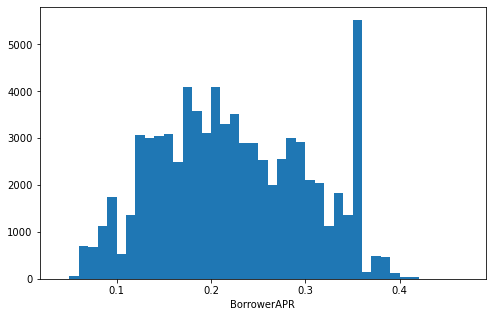

```python
# Plot a hist for BorrowerAPR with bins
bins = np.arange(0.04, prosper['BorrowerAPR'].max()+0.05, 0.01)
plt.figure(figsize=[8, 5])
plt.hist(data = prosper, x = 'BorrowerAPR', bins=bins);
plt.xlabel('BorrowerAPR');
```

The plot appears to be multimodal. Close to 0.1 there is a small peak, right on both sides of 0.2 there are two more peaks and another peak close to 0.3 mark. There is a very high peak at 0.36. The plot shows that very few Borrower APRs are more than 0.4, not more than 100.

#### Next, I'll explore the variables LoanOriginalAmount and StatedMonthlyIncome

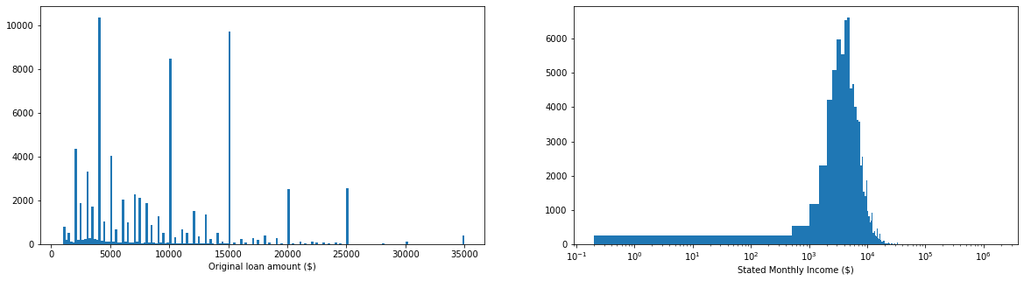

```python
plt.figure(figsize=[20,5])

plt.subplot(1,2,1)
bins = np.arange(800, prosper.LoanOriginalAmount.max()+200, 200)
plt.hist(data = prosper, x = 'LoanOriginalAmount', bins = bins);
plt.xlabel('Original loan amount ($)');


plt.subplot(1,2,2)
s_bins = np.arange(0.2, prosper.StatedMonthlyIncome.max()+500, 500)
plt.hist(data = prosper, x = 'StatedMonthlyIncome', bins = s_bins);
plt.xlabel('Stated Monthly Income ($)');
plt.xscale('log');
```

The minimum wage per month in US has been at least more than 500 dollars since 1980 and over 1000 dollars since 2009. For the purpose of this analysis, let's consider only borrowers with stated monthly income between 1000 and 15000 dollars.

```python
# Return Stated Monthly Income between 1000 and 15000
prosper = prosper[prosper.StatedMonthlyIncome>= 1000]
prosper = prosper[prosper.StatedMonthlyIncome<= 15000]
```

```python
prosper = prosper.reset_index(drop=True)
```

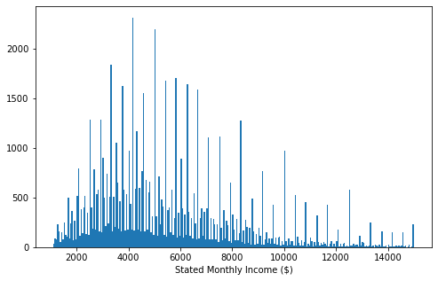

```python
# Plot a new hist for Stated Monthly Income
bins = np.arange(1100, prosper.StatedMonthlyIncome.max()+50, 50);
plt.figure(figsize=[8, 5])
plt.hist(data = prosper, x = 'StatedMonthlyIncome', bins=bins);
plt.xlabel('Stated Monthly Income ($)');
```

The top two highest peaks fall between 4000 to 6000 dollars

##### Let's plot distributions for the qualitative variables (term, prosper rating, loan status) using sns.countplot

#### What is the most common loan term?

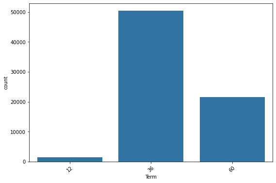

```python
# Function for countplot distributions
def count_plot(data, column_name):
    plt.figure(figsize=[9,6])
    data = prosper
    base_color = sns.color_palette()[0]
    ax = sns.countplot(x = prosper[column_name], color = base_color)
    plt.xticks(rotation=40)
    plt.xlabel(column_name.title())
    plt.show()

count_plot(prosper, 'Term');
```

The most frequent loan term is 36 months

#### Which Prosper rating is the most common?

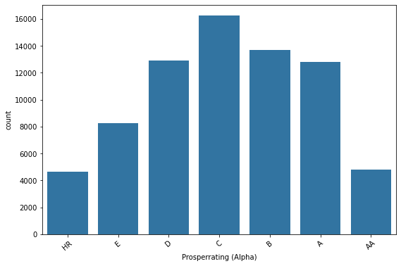

```python
count_plot(prosper, 'ProsperRating (Alpha)');
```

#### What is the most frequent Loan status of borrowers?

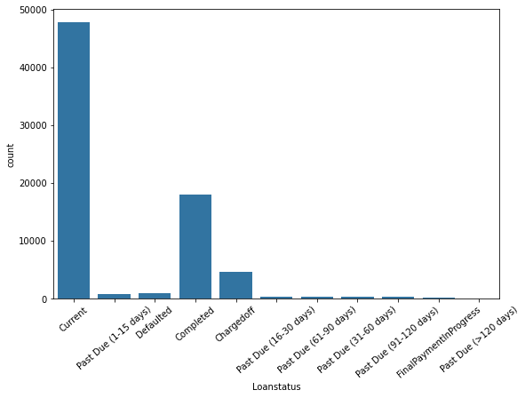

```python
count_plot(prosper, 'LoanStatus');
```

The loan status plot shows that about 90% of the loans are either current or completed and about 10% either past due, defaulted or charged-off.

#### What are the most common and least common employment statuses of borrowers?

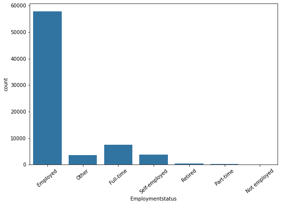

```python
count_plot(prosper, 'EmploymentStatus');
```

```python
employmentstatus_counts = prosper.EmploymentStatus.value_counts()
employmentstatus_counts
```

```
Employed         57899
Full-time         7612
Self-employed     3814
Other             3532
Retired            346
Part-time          176
Not employed         1
Name: EmploymentStatus, dtype: int64
```

```python
sum_employmentstatus = prosper.EmploymentStatus.value_counts().sum()
```

```python
employmentstatus_order = employmentstatus_counts.index
employmentstatus_order
```

```
Index(['Employed', 'Full-time', 'Self-employed', 'Other', 'Retired',
       'Part-time', 'Not employed'],
      dtype='object')
```

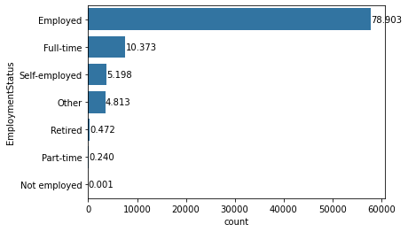

```python
base_color = sns.color_palette()[0]
sns.countplot(data=prosper, y='EmploymentStatus', color=base_color, order=employmentstatus_order);

for i in range (employmentstatus_counts.shape[0]):
    #employmentstatus_counts is the frequency of the values in 'EmploymentStatus' column
    count_ = employmentstatus_counts[i]
    #convert count to percentage, then to string
    prct_string = '{:0.3f}'.format(100*count_/sum_employmentstatus)
    #Print the string value on the bar
    plt.text(count_+1, i, prct_string, va='center');
```

### Of the features you investigated, were there any unusual distributions? Did you perform any operations on the data to tidy, adjust, or change the form of the data? If so, why did you do this?

> The descriptive statistics showed that stated monthly income variable had some unusually high values (outliers). I cleaned the data removing the outliers (as high monthly incomes such as 400,000 had loan amounts of 2000 nd monthly payment plans under 100 dollars) and created a new range from 1000 to 15000 dollars for the purpose of the analysis, which was seen to be multimodal.

## Bivariate Exploration

> In this section, I investigate relationships between Borrower APR against other related variables (quantitative and qualitative). Then I explore other interesting variables.

#### Explore the relationship between Borrower APR and both Original Loan Amount and Stated Monthly Income.

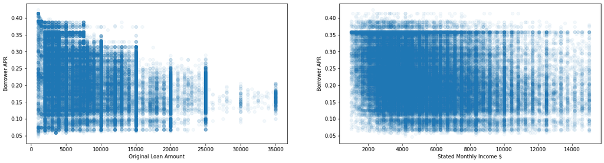

```python
# Scatter plot of Borrower APR against Original Loan Amount
plt.figure(figsize=[20, 5])

plt.subplot(1,2,1)
plt.scatter(data=prosper, y='BorrowerAPR', x='LoanOriginalAmount', alpha=1/20);
plt.ylabel('Borrower APR');
plt.xlabel('Original Loan Amount');

# Scatter plot of Borrower APR against Stated Monthly Income
plt.subplot(1,2,2)
plt.scatter(data=prosper, y='BorrowerAPR', x='StatedMonthlyIncome', alpha=1/20);
plt.ylabel('Borrower APR');
plt.xlabel('Stated Monthly Income $');
```

From the left plot we see that as the loan amount increases the borrower APR range becomes smaller. We observe that loan amounts between 30000 and 35000 have an APR between the range of 0.10 and 0.20.

From the right plot we see that monthly incomes do not seem to really have a strong and clear effect on the APRs. We can use heatmap to explore this further.

#### Use a heatmap to explore Borrower APR and Stated Monthly Income further

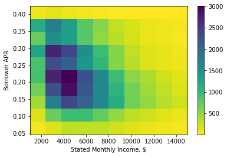

```python
plt.hist2d(data=prosper, x='StatedMonthlyIncome', y='BorrowerAPR', cmin=0.5, cmap='viridis_r');
plt.colorbar()
plt.xlabel('Stated Monthly Income, $');
plt.ylabel('Borrower APR');
```

We see from the heatmap that stated monthly income doesn't have a clear correlation with Borrower APR just as with the scatterplot. However we also see that for incomes between 4000 and 6000, the most frequent APR offered is in the range of 0.12 and 0.22.

##### Explore relationship between Borrower APR and some categorical variables. Further explore relationship between other numeric and categorical variables.

#### How does Prosper Rating affect Borrower APR?

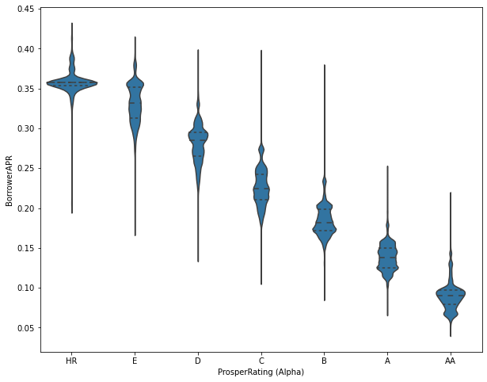

```python
# Violinplot of Borrower APR against Prosper Rating
plt.figure(figsize=[10,8]);
sns.violinplot(data=prosper, x='ProsperRating (Alpha)', y='BorrowerAPR', color=base_color, inner='quartile');
```

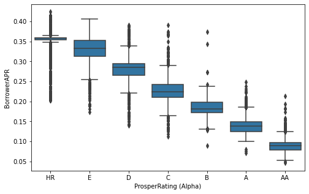

```python
# Boxplot of Prosper rating against Borrower APR
plt.figure(figsize=[8,5]);
sns.boxplot(data=prosper, x='ProsperRating (Alpha)', y='BorrowerAPR', color=base_color);
```

There is a strong correlation between Prosper rating and Borrower APR. The better the Prosper rating, the lower the APR. The median APR for Borrower's with Prosper rating AA is 0.10, although there are some outliers. Overall, the median APR decreases with respect to Prosper Rating from the worst HR to the best rating AA.

#### What is the relationship between Prosper Rating and Stated Monthly Incomes and Loan Amounts?

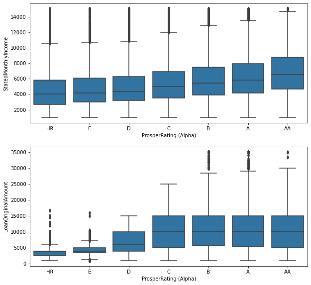

```python
plt.figure(figsize = [10, 15])

# subplot 1: Prosper rating vs Stated Monthly Income
plt.subplot(3, 1, 1)
sns.boxplot(data=prosper, x='ProsperRating (Alpha)', y='StatedMonthlyIncome', color=base_color);

# subplot 2: Prosper rating vs. Original Loan Amount
ax = plt.subplot(3, 1, 2)
sns.boxplot(data=prosper, x='ProsperRating (Alpha)', y='LoanOriginalAmount', color=base_color);
```

#### What is the relationship between Employment Status and Borrower APR, Status Monthly Income, Loan Original Amount?

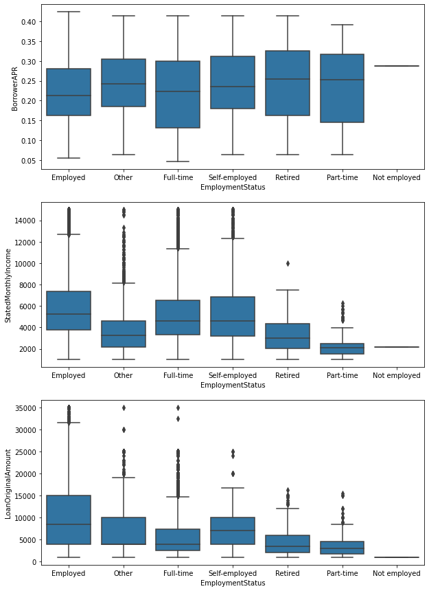

```python
plt.figure(figsize = [10, 15])

# subplot 1: Employment Status vs Borrower APR
plt.subplot(3, 1, 1)
sns.boxplot(data=prosper, x='EmploymentStatus', y='BorrowerAPR', color=base_color);

# subplot 2: Employment Status vs Stated Monthly Income
ax = plt.subplot(3, 1, 2)
sns.boxplot(data=prosper, x='EmploymentStatus', y='StatedMonthlyIncome', color=base_color);

# subplot 2: Emmployment Status vs Original Loan Amount
ax = plt.subplot(3, 1, 3)
sns.boxplot(data=prosper, x='EmploymentStatus', y='LoanOriginalAmount', color=base_color);
```

#### What is the relationship between Loan Term and Borrower APR, Status Monthly Income, Loan Original Amount?

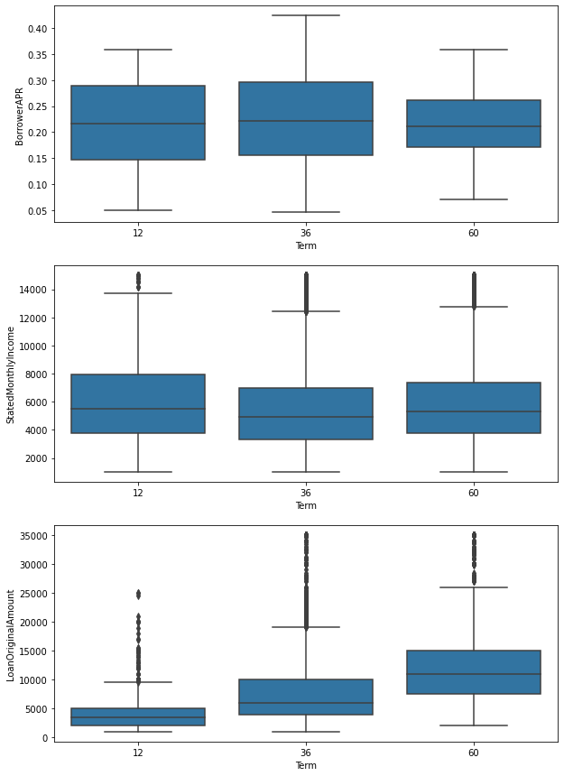

```python
plt.figure(figsize = [10, 15])

# subplot 1: Loan Term vs Borrower APR
plt.subplot(3, 1, 1)
sns.boxplot(data=prosper, x='Term', y='BorrowerAPR', color=base_color);

# subplot 2: Loan Term vs Stated Monthly Income
ax = plt.subplot(3, 1, 2)
sns.boxplot(data=prosper, x='Term', y='StatedMonthlyIncome', color=base_color);

# subplot 3: Loan Term vs. Original Loan Amount
ax = plt.subplot(3, 1, 3)
sns.boxplot(data=prosper, x='Term', y='LoanOriginalAmount', color=base_color);
```

#### What is the relationship between the categorical variables, Prosper Rating, Loan Term and Employment Status?

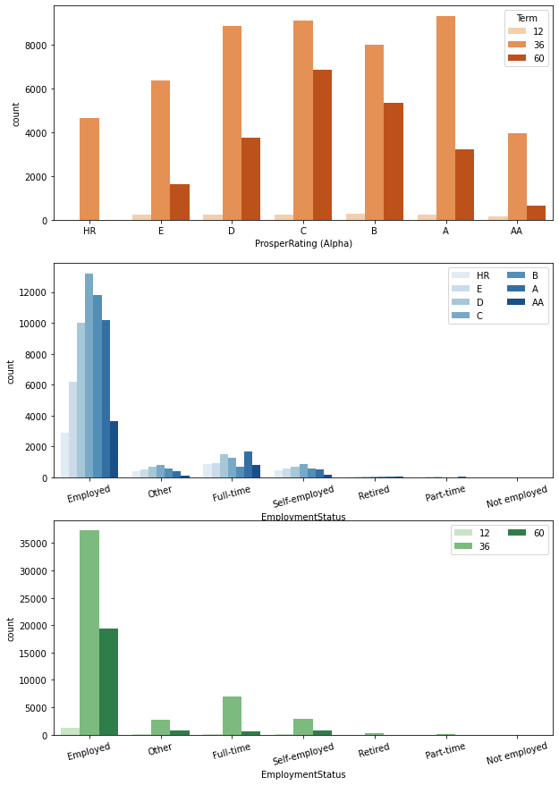

```python
plt.figure(figsize = [10, 15])

# subplot 1: Prosper rating vs Term
plt.subplot(3, 1, 1)
sns.countplot(data = prosper, x = 'ProsperRating (Alpha)', hue = 'Term', palette = 'Oranges');

# subplot 2: Employment status vs Prosper rating
ax = plt.subplot(3, 1, 2)
sns.countplot(data = prosper, x = 'EmploymentStatus', hue = 'ProsperRating (Alpha)', palette = 'Blues');
ax.legend(loc = 1, ncol = 2);
plt.xticks(rotation=15)

# subplot 3: Term vs Employment status
ax = plt.subplot(3, 1, 3)
sns.countplot(data = prosper, x = 'EmploymentStatus', hue = 'Term', palette = 'Greens');
ax.legend(loc = 1, ncol = 2);
plt.xticks(rotation=15);
```

The most common loan term for the various Prosper ratings is 36 months, followed by 60 months. Also, the total count of the worst Prosper rating HR is for the 36-month term.

The most common loan term for employment status types is 36 months.

The mode prosper rating for employed, other and fulltime are C, C and A respectively. There isn't enough data on the remaining employment statuses to made an observation from the plot.

### Talk about some of the relationships you observed in this part of the investigation. How did the feature(s) of interest vary with other features in the dataset?

> From the scatterplot exploring relationship between borrower APR and loan amount we see that as the loan amount increases the borrower APR range becomes smaller. We observe that loan amounts between 30000 and 35000 have an APR between the range of 0.10 and 0.20.

> Using the heatmap and scatterplot we see that stated monthly income doesn't have a clear correlation with Borrower APR, however from the heatmap we observe that for incomes between 4000 and 6000, the most frequent APR offered is in the range of 0.12 and 0.22.

> There is a strong correlation between Prosper rating and Borrower APR. The better the Prosper rating, the lower the APR. The median APR for Borrower's with Prosper rating AA is 0.10, although there are some outliers. Overall, the median borrower APR decreases with respect to Prosper Rating from the worst HR to the best rating AA.

> The median borrowed APRs for all loan terms are very close (a little over the 0.20 mark).

### Did you observe any interesting relationships between the other features (not the main feature(s) of interest)?

> The most common loan term for all Prosper ratings is 36 months. Interestingly, there is only 36 months loans for HR rating borrowers.

## Multivariate Exploration

> I will create a plot to further explore the relationship between borrower APR and original loan amount by introducing the categorical variable 'Term'. I will also do same by introducing 'Prosper ratings' as third variable to see how it affects the above relationship.

> I will also explore further how the two categorical variables, Term and Prosper Rating affect Borrower APR, Loan Amount and Stated Monthly Income.

#### How does Term affect the relationship between Borrower APR and Original Loan Amount?

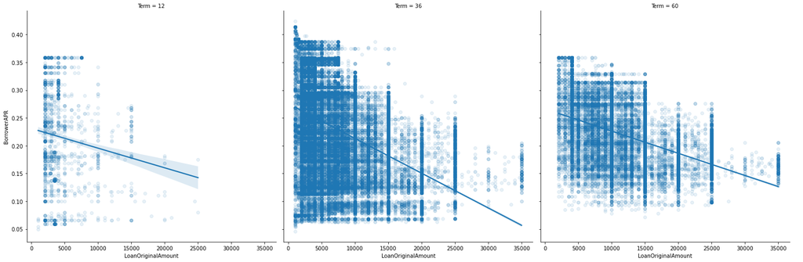

```python
# Use faceting to explore the effect Term can have on the relationship between Borrower APR and loan amount
g=sns.FacetGrid(data=prosper, height=7, col='Term', col_wrap=3);
g.map(sns.regplot, 'LoanOriginalAmount', 'BorrowerAPR', x_jitter=0.04, scatter_kws={'alpha':1/10});
g.add_legend();
```

Overall, the borrower APR range is observed to still reduce as the loan amount increases for all terms. However, for term 60 loans the borrower APR range is seen to be smaller even for smaller loan amounts when compared to terms 36 and 12.

#### How does Prosper Rating affect the relationship between Borrower APR and Original Loan Amount?

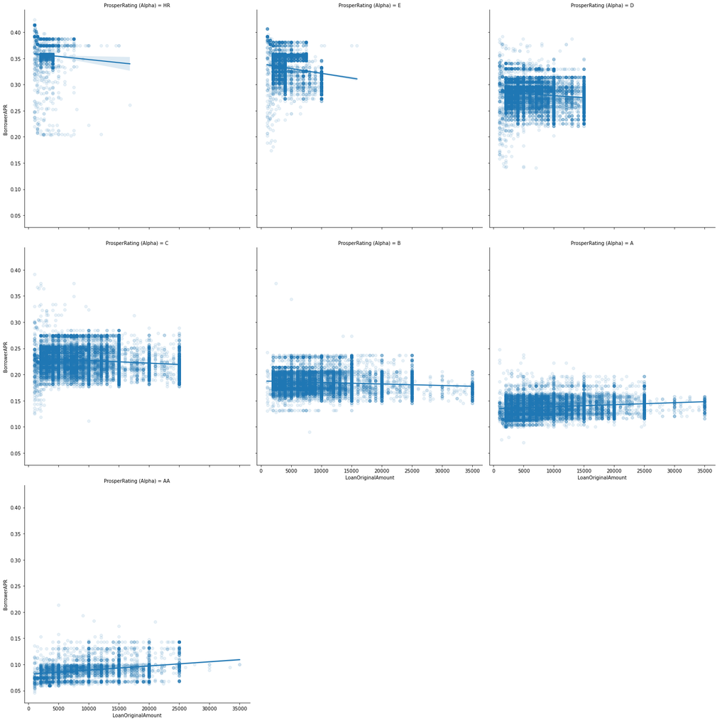

```python
# Use faceting to explore the effect Prosper Rating can have on the relationship between Borrower APR and loan amount
g=sns.FacetGrid(data=prosper, height=7, col='ProsperRating (Alpha)', col_wrap=3);
g.map(sns.regplot, 'LoanOriginalAmount', 'BorrowerAPR', x_jitter=0.04, scatter_kws={'alpha':1/10});
g.add_legend();
```

It is observed that improving Prosper rating (from HR to AA) results in higher loan amounts and improving (lower) borrower APR. However, we also observe that the correlation between the APR and loan amount becomes slightly positive for A and AA ratings, meaning the APR is likely to increase for people with these ratings when they are taking very high loans. Even then, the APR for A and AA ratings are still the least.

#### How is Borrower APR affected by Term and Prosper rating?

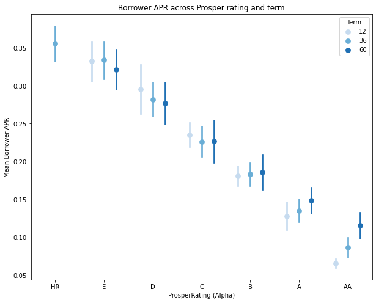

```python
# Explore the relationship between borrower APR, Term and Prosper Rating
fig = plt.figure(figsize = [10,8])
ax = sns.pointplot(data = prosper, x = 'ProsperRating (Alpha)', y = 'BorrowerAPR', hue = 'Term', palette = 'Blues', ci='sd', linestyles = '', dodge = 0.5);
plt.title('Borrower APR across Prosper rating and term')
plt.ylabel('Mean Borrower APR')
ax.set_yticklabels([],minor = True);
```

We observe that the borrower APR decreases with the increasing loan term for borrowers with HR to C ratings. However, for people with B to AA ratings, the borrower APR increases with increasing loan term.

#### How are Loan amounts affected by Term and Prosper rating? Also explore the relationship of Stated monthly incomes with the Term and Prosper rating?

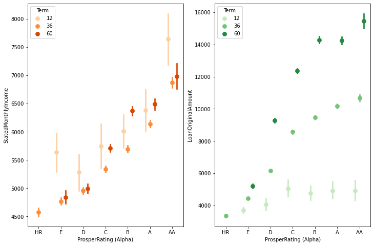

```python
# Plot two pointplots using subplots
fig, ax = plt.subplots(ncols=2, figsize=[12,8])
sns.pointplot(data = prosper, x = 'ProsperRating (Alpha)', y = 'StatedMonthlyIncome', hue = 'Term', palette = 'Oranges', linestyles = '', dodge = 0.4, ax=ax[0]);
sns.pointplot(data = prosper, x = 'ProsperRating (Alpha)', y = 'LoanOriginalAmount', hue = 'Term', palette = 'Greens', linestyles = '', dodge = 0.4, ax=ax[1]);
```

### Talk about some of the relationships you observed in this part of the investigation. Were there features that strengthened each other in terms of looking at your feature(s) of interest?

> Yes, as loan term increases the APR range reduces as the loan amount increases.

> Overall, borrower APR reduces with increasing Prosper rating even as loan amount increases. However, when taking very high loans for A and AA ratings, there is observed to be a slightly higher APR than usual for A and AA ratings which is against the overall trend.

> We also observed that the borrower APR decreases with the increasing loan term for borrowers with HR to C ratings. However, for people with B to AA ratings, the borrower APR increases with increasing loan term.